# Risk Factor Analysis

## Outcome Variable

**Outcome Variable:** wast_rec90d

## Predictor Variables

**Intervention Variable:** predfeed36

**Adjustment Set:**

- arm
- sex
- month
- brthmon
- W_mage
- meducyrs
- feducyrs
- hhwealth_quart
- hfoodsec
- W_mhtcm
- vagbrth
- W_gagebrth
- W_birthwt
- W_birthlen
- W_nrooms
- W_nchldlt5
- W_parity
- impfloor
- impsan
- safeh20
- delta_W_mage
- delta_meducyrs
- delta_feducyrs
- delta_hhwealth_quart
- delta_hfoodsec
- delta_W_mhtcm
- delta_vagbrth
- delta_W_gagebrth
- delta_W_birthwt
- delta_W_birthlen
- delta_W_nrooms
- delta_W_nchldlt5
- delta_W_parity
- delta_impfloor
- delta_impsan
- delta_safeh20

## Stratifying Variables

The analysis was stratified on these variable(s):

- agecat
- studyid
- country

## Data Summary

| agecat | studyid | country | predfeed36 | wast_rec90d | n_cell | n |
| --- | --- | --- | --- | --- | --- | --- |
| 0-24 months | ki0047075b-MAL-ED | BANGLADESH | 0 | 0 | 19 | 122 |
| 0-24 months | ki0047075b-MAL-ED | BANGLADESH | 0 | 1 | 34 | 122 |
| 0-24 months | ki0047075b-MAL-ED | BANGLADESH | 1 | 0 | 25 | 122 |
| 0-24 months | ki0047075b-MAL-ED | BANGLADESH | 1 | 1 | 44 | 122 |
| 0-24 months | ki0047075b-MAL-ED | BRAZIL | 0 | 0 | 5 | 23 |
| 0-24 months | ki0047075b-MAL-ED | BRAZIL | 0 | 1 | 17 | 23 |
| 0-24 months | ki0047075b-MAL-ED | BRAZIL | 1 | 0 | 1 | 23 |
| 0-24 months | ki0047075b-MAL-ED | BRAZIL | 1 | 1 | 0 | 23 |
| 0-24 months | ki0047075b-MAL-ED | INDIA | 0 | 0 | 68 | 177 |
| 0-24 months | ki0047075b-MAL-ED | INDIA | 0 | 1 | 97 | 177 |
| 0-24 months | ki0047075b-MAL-ED | INDIA | 1 | 0 | 2 | 177 |
| 0-24 months | ki0047075b-MAL-ED | INDIA | 1 | 1 | 10 | 177 |
| 0-24 months | ki0047075b-MAL-ED | NEPAL | 0 | 0 | 19 | 93 |
| 0-24 months | ki0047075b-MAL-ED | NEPAL | 0 | 1 | 68 | 93 |
| 0-24 months | ki0047075b-MAL-ED | NEPAL | 1 | 0 | 1 | 93 |
| 0-24 months | ki0047075b-MAL-ED | NEPAL | 1 | 1 | 5 | 93 |
| 0-24 months | ki0047075b-MAL-ED | PERU | 0 | 0 | 5 | 32 |
| 0-24 months | ki0047075b-MAL-ED | PERU | 0 | 1 | 21 | 32 |
| 0-24 months | ki0047075b-MAL-ED | PERU | 1 | 0 | 1 | 32 |
| 0-24 months | ki0047075b-MAL-ED | PERU | 1 | 1 | 5 | 32 |
| 0-24 months | ki0047075b-MAL-ED | SOUTH AFRICA | 0 | 0 | 13 | 78 |
| 0-24 months | ki0047075b-MAL-ED | SOUTH AFRICA | 0 | 1 | 65 | 78 |
| 0-24 months | ki0047075b-MAL-ED | SOUTH AFRICA | 1 | 0 | 0 | 78 |
| 0-24 months | ki0047075b-MAL-ED | SOUTH AFRICA | 1 | 1 | 0 | 78 |
| 0-24 months | ki0047075b-MAL-ED | TANZANIA, UNITED REPUBLIC OF | 0 | 0 | 8 | 45 |
| 0-24 months | ki0047075b-MAL-ED | TANZANIA, UNITED REPUBLIC OF | 0 | 1 | 37 | 45 |
| 0-24 months | ki0047075b-MAL-ED | TANZANIA, UNITED REPUBLIC OF | 1 | 0 | 0 | 45 |
| 0-24 months | ki0047075b-MAL-ED | TANZANIA, UNITED REPUBLIC OF | 1 | 1 | 0 | 45 |
| 0-24 months | ki1000109-EE | PAKISTAN | 0 | 0 | 136 | 510 |
| 0-24 months | ki1000109-EE | PAKISTAN | 0 | 1 | 82 | 510 |

[output cut: 126 more lines]

The following strata were considered:

- agecat: 0-24 months, studyid: ki0047075b-MAL-ED, country: BANGLADESH
- agecat: 0-24 months, studyid: ki0047075b-MAL-ED, country: BRAZIL
- agecat: 0-24 months, studyid: ki0047075b-MAL-ED, country: INDIA
- agecat: 0-24 months, studyid: ki0047075b-MAL-ED, country: NEPAL
- agecat: 0-24 months, studyid: ki0047075b-MAL-ED, country: PERU
- agecat: 0-24 months, studyid: ki0047075b-MAL-ED, country: SOUTH AFRICA
- agecat: 0-24 months, studyid: ki0047075b-MAL-ED, country: TANZANIA, UNITED REPUBLIC OF
- agecat: 0-24 months, studyid: ki1000109-EE, country: PAKISTAN
- agecat: 0-24 months, studyid: ki1000304b-SAS-FoodSuppl, country: INDIA
- agecat: 0-24 months, studyid: ki1113344-GMS-Nepal, country: NEPAL
- agecat: 0-24 months, studyid: ki1148112-LCNI-5, country: MALAWI
- agecat: 0-24 months, studyid: kiGH5241-JiVitA-3, country: BANGLADESH
- agecat: 0-24 months, studyid: kiGH5241-JiVitA-4, country: BANGLADESH
- agecat: 0-6 months, studyid: ki0047075b-MAL-ED, country: BANGLADESH
- agecat: 0-6 months, studyid: ki0047075b-MAL-ED, country: BRAZIL
- agecat: 0-6 months, studyid: ki0047075b-MAL-ED, country: INDIA
- agecat: 0-6 months, studyid: ki0047075b-MAL-ED, country: NEPAL
- agecat: 0-6 months, studyid: ki0047075b-MAL-ED, country: PERU
- agecat: 0-6 months, studyid: ki0047075b-MAL-ED, country: SOUTH AFRICA
- agecat: 0-6 months, studyid: ki0047075b-MAL-ED, country: TANZANIA, UNITED REPUBLIC OF
- agecat: 0-6 months, studyid: ki1000109-EE, country: PAKISTAN
- agecat: 0-6 months, studyid: ki1000304b-SAS-FoodSuppl, country: INDIA
- agecat: 0-6 months, studyid: ki1113344-GMS-Nepal, country: NEPAL
- agecat: 0-6 months, studyid: ki1148112-LCNI-5, country: MALAWI
- agecat: 0-6 months, studyid: kiGH5241-JiVitA-3, country: BANGLADESH
- agecat: 0-6 months, studyid: kiGH5241-JiVitA-4, country: BANGLADESH
- agecat: 6-24 months, studyid: ki0047075b-MAL-ED, country: BANGLADESH
- agecat: 6-24 months, studyid: ki0047075b-MAL-ED, country: BRAZIL
- agecat: 6-24 months, studyid: ki0047075b-MAL-ED, country: INDIA
- agecat: 6-24 months, studyid: ki0047075b-MAL-ED, country: NEPAL
- agecat: 6-24 months, studyid: ki0047075b-MAL-ED, country: PERU
- agecat: 6-24 months, studyid: ki0047075b-MAL-ED, country: SOUTH AFRICA
- agecat: 6-24 months, studyid: ki0047075b-MAL-ED, country: TANZANIA, UNITED REPUBLIC OF
- agecat: 6-24 months, studyid: ki1000109-EE, country: PAKISTAN
- agecat: 6-24 months, studyid: ki1000304b-SAS-FoodSuppl, country: INDIA
- agecat: 6-24 months, studyid: ki1113344-GMS-Nepal, country: NEPAL
- agecat: 6-24 months, studyid: ki1148112-LCNI-5, country: MALAWI
- agecat: 6-24 months, studyid: kiGH5241-JiVitA-3, country: BANGLADESH
- agecat: 6-24 months, studyid: kiGH5241-JiVitA-4, country: BANGLADESH

### Dropped Strata

Some strata were dropped due to rare outcomes:

- agecat: 0-24 months, studyid: ki0047075b-MAL-ED, country: BRAZIL
- agecat: 0-24 months, studyid: ki0047075b-MAL-ED, country: INDIA
- agecat: 0-24 months, studyid: ki0047075b-MAL-ED, country: NEPAL
- agecat: 0-24 months, studyid: ki0047075b-MAL-ED, country: PERU
- agecat: 0-24 months, studyid: ki0047075b-MAL-ED, country: SOUTH AFRICA
- agecat: 0-24 months, studyid: ki0047075b-MAL-ED, country: TANZANIA, UNITED REPUBLIC OF
- agecat: 0-24 months, studyid: ki1000304b-SAS-FoodSuppl, country: INDIA
- agecat: 0-24 months, studyid: ki1148112-LCNI-5, country: MALAWI
- agecat: 0-6 months, studyid: ki0047075b-MAL-ED, country: BRAZIL
- agecat: 0-6 months, studyid: ki0047075b-MAL-ED, country: INDIA
- agecat: 0-6 months, studyid: ki0047075b-MAL-ED, country: NEPAL
- agecat: 0-6 months, studyid: ki0047075b-MAL-ED, country: PERU
- agecat: 0-6 months, studyid: ki0047075b-MAL-ED, country: SOUTH AFRICA
- agecat: 0-6 months, studyid: ki0047075b-MAL-ED, country: TANZANIA, UNITED REPUBLIC OF
- agecat: 0-6 months, studyid: ki1000304b-SAS-FoodSuppl, country: INDIA
- agecat: 0-6 months, studyid: ki1148112-LCNI-5, country: MALAWI
- agecat: 6-24 months, studyid: ki0047075b-MAL-ED, country: BRAZIL
- agecat: 6-24 months, studyid: ki0047075b-MAL-ED, country: INDIA
- agecat: 6-24 months, studyid: ki0047075b-MAL-ED, country: NEPAL
- agecat: 6-24 months, studyid: ki0047075b-MAL-ED, country: PERU
- agecat: 6-24 months, studyid: ki0047075b-MAL-ED, country: SOUTH AFRICA
- agecat: 6-24 months, studyid: ki0047075b-MAL-ED, country: TANZANIA, UNITED REPUBLIC OF
- agecat: 6-24 months, studyid: ki1000304b-SAS-FoodSuppl, country: INDIA
- agecat: 6-24 months, studyid: ki1148112-LCNI-5, country: MALAWI
- agecat: 6-24 months, studyid: kiGH5241-JiVitA-3, country: BANGLADESH

## Methods Detail

We’re interested in the causal parameters $E[Y_a]$ for all values of $a \in \mathcal{A}$. These parameters represent the mean outcome if, possibly contrary to fact, we intervened to set all units to have $A=a$. Under the randomization and positivity assumptions, these are identified by the statistical parameters $\psi_a=E_W[E_{Y|A,W}(Y|A=a,W)]$. In addition, we’re interested in the mean of $Y$, $E[Y]$ under no intervention (the observed mean). We will estimate these parameters by using SuperLearner to fit the relevant likelihood factors – $E_{Y|A,W}(Y|A=a,W)$ and $p(A=a|W)$, and then updating our likelihood fit using a joint TMLE.

For unadjusted analyses ($W=\{\}$), initial likelihoods were estimated using Lrnr_glm to estimate the simple $E(Y|A)$ and Lrnr_mean to estimate $p(A)$. For adjusted analyses, a small library containing Lrnr_glmnet, Lrnr_xgboost, and Lrnr_mean was used.

Having estimated these parameters, we will then use the delta method to estimate relative risks and attributable risks relative to a prespecified baseline level of $A$.

# Results Detail

## Results Plots

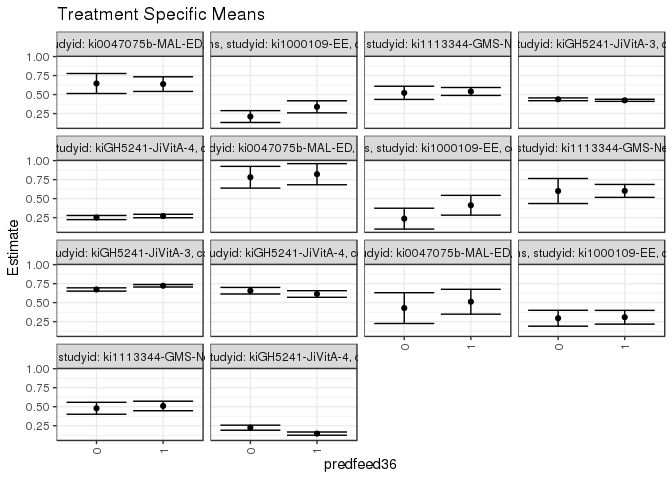

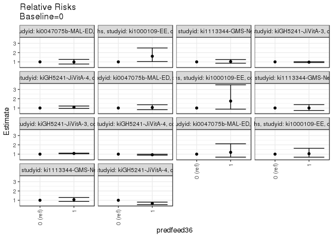

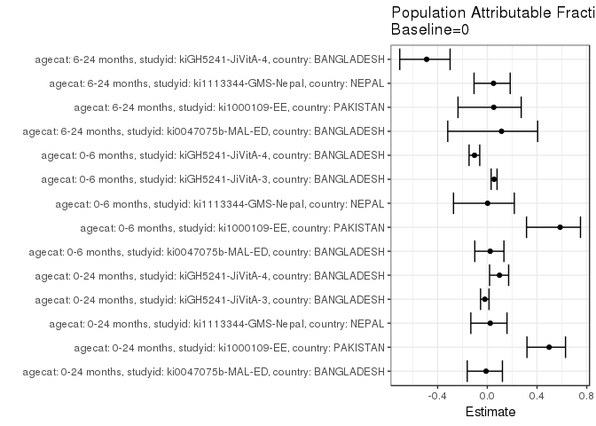

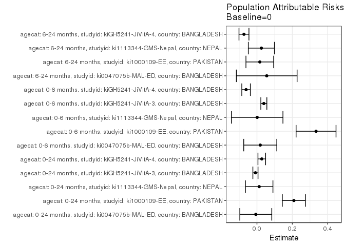

## Results Table

### Parameter: TSM

| agecat | studyid | country | intervention_level | baseline_level | estimate | ci_lower | ci_upper |
| --- | --- | --- | --- | --- | --- | --- | --- |
| 0-24 months | ki0047075b-MAL-ED | BANGLADESH | 0 | NA | 0.6458558 | 0.5142771 | 0.7774344 |
| 0-24 months | ki0047075b-MAL-ED | BANGLADESH | 1 | NA | 0.6376783 | 0.5415948 | 0.7337618 |
| 0-24 months | ki1000109-EE | PAKISTAN | 0 | NA | 0.2108077 | 0.1328092 | 0.2888062 |
| 0-24 months | ki1000109-EE | PAKISTAN | 1 | NA | 0.3387854 | 0.2594719 | 0.4180989 |
| 0-24 months | ki1113344-GMS-Nepal | NEPAL | 0 | NA | 0.5229988 | 0.4359604 | 0.6100372 |
| 0-24 months | ki1113344-GMS-Nepal | NEPAL | 1 | NA | 0.5409032 | 0.4886466 | 0.5931599 |
| 0-24 months | kiGH5241-JiVitA-3 | BANGLADESH | 0 | NA | 0.4377522 | 0.4193727 | 0.4561318 |
| 0-24 months | kiGH5241-JiVitA-3 | BANGLADESH | 1 | NA | 0.4243628 | 0.4105229 | 0.4382027 |
| 0-24 months | kiGH5241-JiVitA-4 | BANGLADESH | 0 | NA | 0.2509116 | 0.2235130 | 0.2783102 |
| 0-24 months | kiGH5241-JiVitA-4 | BANGLADESH | 1 | NA | 0.2707293 | 0.2478368 | 0.2936219 |
| 0-6 months | ki0047075b-MAL-ED | BANGLADESH | 0 | NA | 0.7812500 | 0.6381241 | 0.9243759 |
| 0-6 months | ki0047075b-MAL-ED | BANGLADESH | 1 | NA | 0.8214286 | 0.6823152 | 0.9605419 |
| 0-6 months | ki1000109-EE | PAKISTAN | 0 | NA | 0.2359876 | 0.0986708 | 0.3733044 |
| 0-6 months | ki1000109-EE | PAKISTAN | 1 | NA | 0.4126121 | 0.2823002 | 0.5429240 |
| 0-6 months | ki1113344-GMS-Nepal | NEPAL | 0 | NA | 0.6000000 | 0.4351707 | 0.7648293 |
| 0-6 months | ki1113344-GMS-Nepal | NEPAL | 1 | NA | 0.6015625 | 0.5163730 | 0.6867520 |
| 0-6 months | kiGH5241-JiVitA-3 | BANGLADESH | 0 | NA | 0.6732477 | 0.6516594 | 0.6948361 |
| 0-6 months | kiGH5241-JiVitA-3 | BANGLADESH | 1 | NA | 0.7223024 | 0.7060585 | 0.7385462 |
| 0-6 months | kiGH5241-JiVitA-4 | BANGLADESH | 0 | NA | 0.6571776 | 0.6139020 | 0.7004532 |
| 0-6 months | kiGH5241-JiVitA-4 | BANGLADESH | 1 | NA | 0.6139294 | 0.5702887 | 0.6575700 |
| 6-24 months | ki0047075b-MAL-ED | BANGLADESH | 0 | NA | 0.4285714 | 0.2258750 | 0.6312678 |
| 6-24 months | ki0047075b-MAL-ED | BANGLADESH | 1 | NA | 0.5121951 | 0.3484618 | 0.6759284 |
| 6-24 months | ki1000109-EE | PAKISTAN | 0 | NA | 0.2947049 | 0.1900777 | 0.3993320 |
| 6-24 months | ki1000109-EE | PAKISTAN | 1 | NA | 0.3080098 | 0.2174295 | 0.3985902 |
| 6-24 months | ki1113344-GMS-Nepal | NEPAL | 0 | NA | 0.4793380 | 0.4007477 | 0.5579282 |
| 6-24 months | ki1113344-GMS-Nepal | NEPAL | 1 | NA | 0.5095846 | 0.4469710 | 0.5721982 |
| 6-24 months | kiGH5241-JiVitA-4 | BANGLADESH | 0 | NA | 0.2236934 | 0.1907287 | 0.2566581 |
| 6-24 months | kiGH5241-JiVitA-4 | BANGLADESH | 1 | NA | 0.1457431 | 0.1245696 | 0.1669165 |

### Parameter: E(Y)

| agecat | studyid | country | intervention_level | baseline_level | estimate | ci_lower | ci_upper |
| --- | --- | --- | --- | --- | --- | --- | --- |
| 0-24 months | ki0047075b-MAL-ED | BANGLADESH | NA | NA | 0.6393443 | 0.5530901 | 0.7255985 |
| 0-24 months | ki1000109-EE | PAKISTAN | NA | NA | 0.4196078 | 0.3541827 | 0.4850330 |
| 0-24 months | ki1113344-GMS-Nepal | NEPAL | NA | NA | 0.5355731 | 0.4882587 | 0.5828875 |
| 0-24 months | kiGH5241-JiVitA-3 | BANGLADESH | NA | NA | 0.4292213 | 0.4164001 | 0.4420426 |
| 0-24 months | kiGH5241-JiVitA-4 | BANGLADESH | NA | NA | 0.2781828 | 0.2567503 | 0.2996153 |
| 0-6 months | ki0047075b-MAL-ED | BANGLADESH | NA | NA | 0.8000000 | 0.6995926 | 0.9004074 |
| 0-6 months | ki1000109-EE | PAKISTAN | NA | NA | 0.5700935 | 0.4742263 | 0.6659606 |
| 0-6 months | ki1113344-GMS-Nepal | NEPAL | NA | NA | 0.6012270 | 0.5255442 | 0.6769098 |
| 0-6 months | kiGH5241-JiVitA-3 | BANGLADESH | NA | NA | 0.7122532 | 0.6971343 | 0.7273720 |
| 0-6 months | kiGH5241-JiVitA-4 | BANGLADESH | NA | NA | 0.5957031 | 0.5531528 | 0.6382534 |
| 6-24 months | ki0047075b-MAL-ED | BANGLADESH | NA | NA | 0.4838710 | 0.3544124 | 0.6133295 |
| 6-24 months | ki1000109-EE | PAKISTAN | NA | NA | 0.3108108 | 0.2352987 | 0.3863229 |
| 6-24 months | ki1113344-GMS-Nepal | NEPAL | NA | NA | 0.5043732 | 0.4466684 | 0.5620780 |
| 6-24 months | kiGH5241-JiVitA-4 | BANGLADESH | NA | NA | 0.1502754 | 0.1309788 | 0.1695719 |

### Parameter: RR

| agecat | studyid | country | intervention_level | baseline_level | estimate | ci_lower | ci_upper |
| --- | --- | --- | --- | --- | --- | --- | --- |
| 0-24 months | ki0047075b-MAL-ED | BANGLADESH | 0 | 0 | 1.0000000 | 1.0000000 | 1.0000000 |
| 0-24 months | ki0047075b-MAL-ED | BANGLADESH | 1 | 0 | 0.9873385 | 0.7661854 | 1.2723257 |
| 0-24 months | ki1000109-EE | PAKISTAN | 0 | 0 | 1.0000000 | 1.0000000 | 1.0000000 |
| 0-24 months | ki1000109-EE | PAKISTAN | 1 | 0 | 1.6070831 | 1.0322980 | 2.5019092 |
| 0-24 months | ki1113344-GMS-Nepal | NEPAL | 0 | 0 | 1.0000000 | 1.0000000 | 1.0000000 |
| 0-24 months | ki1113344-GMS-Nepal | NEPAL | 1 | 0 | 1.0342342 | 0.8556056 | 1.2501559 |
| 0-24 months | kiGH5241-JiVitA-3 | BANGLADESH | 0 | 0 | 1.0000000 | 1.0000000 | 1.0000000 |
| 0-24 months | kiGH5241-JiVitA-3 | BANGLADESH | 1 | 0 | 0.9694132 | 0.9251686 | 1.0157736 |
| 0-24 months | kiGH5241-JiVitA-4 | BANGLADESH | 0 | 0 | 1.0000000 | 1.0000000 | 1.0000000 |
| 0-24 months | kiGH5241-JiVitA-4 | BANGLADESH | 1 | 0 | 1.0789831 | 0.9585051 | 1.2146044 |
| 0-6 months | ki0047075b-MAL-ED | BANGLADESH | 0 | 0 | 1.0000000 | 1.0000000 | 1.0000000 |
| 0-6 months | ki0047075b-MAL-ED | BANGLADESH | 1 | 0 | 1.0514286 | 0.8192646 | 1.3493833 |
| 0-6 months | ki1000109-EE | PAKISTAN | 0 | 0 | 1.0000000 | 1.0000000 | 1.0000000 |
| 0-6 months | ki1000109-EE | PAKISTAN | 1 | 0 | 1.7484485 | 0.8742401 | 3.4968334 |
| 0-6 months | ki1113344-GMS-Nepal | NEPAL | 0 | 0 | 1.0000000 | 1.0000000 | 1.0000000 |
| 0-6 months | ki1113344-GMS-Nepal | NEPAL | 1 | 0 | 1.0026042 | 0.7360426 | 1.3657023 |
| 0-6 months | kiGH5241-JiVitA-3 | BANGLADESH | 0 | 0 | 1.0000000 | 1.0000000 | 1.0000000 |
| 0-6 months | kiGH5241-JiVitA-3 | BANGLADESH | 1 | 0 | 1.0728627 | 1.0354861 | 1.1115883 |
| 0-6 months | kiGH5241-JiVitA-4 | BANGLADESH | 0 | 0 | 1.0000000 | 1.0000000 | 1.0000000 |
| 0-6 months | kiGH5241-JiVitA-4 | BANGLADESH | 1 | 0 | 0.9341909 | 0.8828853 | 0.9884779 |
| 6-24 months | ki0047075b-MAL-ED | BANGLADESH | 0 | 0 | 1.0000000 | 1.0000000 | 1.0000000 |
| 6-24 months | ki0047075b-MAL-ED | BANGLADESH | 1 | 0 | 1.1951219 | 0.6752625 | 2.1152018 |
| 6-24 months | ki1000109-EE | PAKISTAN | 0 | 0 | 1.0000000 | 1.0000000 | 1.0000000 |
| 6-24 months | ki1000109-EE | PAKISTAN | 1 | 0 | 1.0451467 | 0.6705198 | 1.6290820 |
| 6-24 months | ki1113344-GMS-Nepal | NEPAL | 0 | 0 | 1.0000000 | 1.0000000 | 1.0000000 |
| 6-24 months | ki1113344-GMS-Nepal | NEPAL | 1 | 0 | 1.0631009 | 0.8720880 | 1.2959512 |
| 6-24 months | kiGH5241-JiVitA-4 | BANGLADESH | 0 | 0 | 1.0000000 | 1.0000000 | 1.0000000 |
| 6-24 months | kiGH5241-JiVitA-4 | BANGLADESH | 1 | 0 | 0.6515304 | 0.5296706 | 0.8014263 |

### Parameter: PAR

| agecat | studyid | country | intervention_level | baseline_level | estimate | ci_lower | ci_upper |
| --- | --- | --- | --- | --- | --- | --- | --- |
| 0-24 months | ki0047075b-MAL-ED | BANGLADESH | 0 | NA | -0.0065115 | -0.0968309 | 0.0838078 |
| 0-24 months | ki1000109-EE | PAKISTAN | 0 | NA | 0.2088002 | 0.1433459 | 0.2742545 |
| 0-24 months | ki1113344-GMS-Nepal | NEPAL | 0 | NA | 0.0125743 | -0.0651851 | 0.0903337 |
| 0-24 months | kiGH5241-JiVitA-3 | BANGLADESH | 0 | NA | -0.0085309 | -0.0230901 | 0.0060283 |
| 0-24 months | kiGH5241-JiVitA-4 | BANGLADESH | 0 | NA | 0.0272713 | 0.0056810 | 0.0488615 |
| 0-6 months | ki0047075b-MAL-ED | BANGLADESH | 0 | NA | 0.0187500 | -0.0746467 | 0.1121467 |
| 0-6 months | ki1000109-EE | PAKISTAN | 0 | NA | 0.3341059 | 0.2212114 | 0.4470004 |
| 0-6 months | ki1113344-GMS-Nepal | NEPAL | 0 | NA | 0.0012270 | -0.1444749 | 0.1469289 |
| 0-6 months | kiGH5241-JiVitA-3 | BANGLADESH | 0 | NA | 0.0390055 | 0.0220112 | 0.0559998 |
| 0-6 months | kiGH5241-JiVitA-4 | BANGLADESH | 0 | NA | -0.0614745 | -0.0855895 | -0.0373594 |
| 6-24 months | ki0047075b-MAL-ED | BANGLADESH | 0 | NA | 0.0552995 | -0.1163127 | 0.2269118 |
| 6-24 months | ki1000109-EE | PAKISTAN | 0 | NA | 0.0161059 | -0.0622220 | 0.0944339 |
| 6-24 months | ki1113344-GMS-Nepal | NEPAL | 0 | NA | 0.0250352 | -0.0489220 | 0.0989924 |
| 6-24 months | kiGH5241-JiVitA-4 | BANGLADESH | 0 | NA | -0.0734180 | -0.1015900 | -0.0452460 |

### Parameter: PAF

| agecat | studyid | country | intervention_level | baseline_level | estimate | ci_lower | ci_upper |
| --- | --- | --- | --- | --- | --- | --- | --- |
| 0-24 months | ki0047075b-MAL-ED | BANGLADESH | 0 | NA | -0.0101847 | -0.1616418 | 0.1215252 |
| 0-24 months | ki1000109-EE | PAKISTAN | 0 | NA | 0.4976079 | 0.3190563 | 0.6293411 |
| 0-24 months | ki1113344-GMS-Nepal | NEPAL | 0 | NA | 0.0234783 | -0.1328446 | 0.1582299 |
| 0-24 months | kiGH5241-JiVitA-3 | BANGLADESH | 0 | NA | -0.0198753 | -0.0544344 | 0.0135511 |
| 0-24 months | kiGH5241-JiVitA-4 | BANGLADESH | 0 | NA | 0.0980336 | 0.0181464 | 0.1714209 |
| 0-6 months | ki0047075b-MAL-ED | BANGLADESH | 0 | NA | 0.0234375 | -0.1009118 | 0.1337414 |
| 0-6 months | ki1000109-EE | PAKISTAN | 0 | NA | 0.5860546 | 0.3153868 | 0.7497115 |
| 0-6 months | ki1113344-GMS-Nepal | NEPAL | 0 | NA | 0.0020408 | -0.2722617 | 0.2172031 |
| 0-6 months | kiGH5241-JiVitA-3 | BANGLADESH | 0 | NA | 0.0547635 | 0.0306901 | 0.0782390 |
| 0-6 months | kiGH5241-JiVitA-4 | BANGLADESH | 0 | NA | -0.1031965 | -0.1469864 | -0.0610784 |
| 6-24 months | ki0047075b-MAL-ED | BANGLADESH | 0 | NA | 0.1142857 | -0.3185948 | 0.4050562 |
| 6-24 months | ki1000109-EE | PAKISTAN | 0 | NA | 0.0518191 | -0.2360314 | 0.2726342 |
| 6-24 months | ki1113344-GMS-Nepal | NEPAL | 0 | NA | 0.0496363 | -0.1069954 | 0.1841057 |
| 6-24 months | kiGH5241-JiVitA-4 | BANGLADESH | 0 | NA | -0.4885566 | -0.7048842 | -0.2996782 |